# Problem Set 3

### Before You Start

Make sure the following libraries load correctly (hit Ctrl-Enter). Note that while you are loading several powerful libraries, including machine learning libraries, the goal of this problem set is to implement several algorithms from scratch. In particular, you should *not* be using any built-in libraries for nearest neighbors, distance metrics, or cross-validation -- your mission is to write those algorithms in Python! Parts 1 and 2 will be relatively easy; Part 3 will take more time.

*Also note:* For this assignment we are requiring you to use base **matplotlib** - no more Seaborn or other packages. This will help you become familiar with techniques for maintaining fine-grained control over your data visualizations. It will also help our graders, who spent countless hours trying to make various versions import for grading.

```python
import IPython
import numpy as np
import scipy as sp
import pandas as pd
import matplotlib
import sklearn
import math
from sklearn.model_selection import train_test_split
```

## Introduction to the assignment

For this assignment, you will be using the Boston Housing Prices Data Set. This used to be housed by [UCI Machine Learning Repository](http://archive.ics.uci.edu/ml/datasets/Housing), but it is not housed there any more. You can read about it at [Kaggle](https://www.kaggle.com/vikrishnan/boston-house-prices) and at the [University of Toronto](https://www.cs.toronto.edu/~delve/data/boston/bostonDetail.html). Please read about the dataset carefully before continuing. Use the following commands to load the dataset:

```python
from sklearn.datasets import load_boston
bdata = load_boston()
```

The following commands will provide some basic information about the shape of the data:

```python
print(bdata.keys())
print(bdata.feature_names)
print(bdata.data.shape)
print(bdata.target.shape)
# uncomment the following if you want to see a lengthy description of the dataset
print(bdata.DESCR)
```

```
dict_keys(['data', 'target', 'feature_names', 'DESCR'])
['CRIM' 'ZN' 'INDUS' 'CHAS' 'NOX' 'RM' 'AGE' 'DIS' 'RAD' 'TAX' 'PTRATIO'
 'B' 'LSTAT']
(506, 13)
(506,)
Boston House Prices dataset
===========================

Notes
------
Data Set Characteristics:

    :Number of Instances: 506

    :Number of Attributes: 13 numeric/categorical predictive

    :Median Value (attribute 14) is usually the target

    :Attribute Information (in order):
        - CRIM     per capita crime rate by town
        - ZN       proportion of residential land zoned for lots over 25,000 sq.ft.
        - INDUS    proportion of non-retail business acres per town
        - CHAS     Charles River dummy variable (= 1 if tract bounds river; 0 otherwise)
        - NOX      nitric oxides concentration (parts per 10 million)
        - RM       average number of rooms per dwelling
        - AGE      proportion of owner-occupied units built prior to 1940
        - DIS      weighted distances to five Boston employment centres
        - RAD      index of accessibility to radial highways
        - TAX      full-value property-tax rate per $10,000
        - PTRATIO  pupil-teacher ratio by town
        - B        1000(Bk - 0.63)^2 where Bk is the proportion of blacks by town
        - LSTAT    % lower status of the population
        - MEDV     Median value of owner-occupied homes in $1000's

    :Missing Attribute Values: None

    :Creator: Harrison, D. and Rubinfeld, D.L.

This is a copy of UCI ML housing dataset.
http://archive.ics.uci.edu/ml/datasets/Housing


This dataset was taken from the StatLib library which is maintained at Carnegie Mellon University.

The Boston house-price data of Harrison, D. and Rubinfeld, D.L. 'Hedonic
prices and the demand for clean air', J. Environ. Economics & Management,
vol.5, 81-102, 1978.   Used in Belsley, Kuh & Welsch, 'Regression diagnostics
...', Wiley, 1980.   N.B. Various transformations are used in the table on
pages 244-261 of the latter.

The Boston house-price data has been used in many machine learning papers that address regression
problems.

**References**

   - Belsley, Kuh & Welsch, 'Regression diagnostics: Identifying Influential Data and Sources of Collinearity', Wiley, 1980. 244-261.
   - Quinlan,R. (1993). Combining Instance-Based and Model-Based Learning. In Proceedings on the Tenth International Conference of Machine Learning, 236-243, University of Massachusetts, Amherst. Morgan Kaufmann.
   - many more! (see http://archive.ics.uci.edu/ml/datasets/Housing)
```

## Part 1: Descriptive analysis

Before beginning the "real" work, dig into the data a bit do see what you're dealing with. If you feel that you are still in the beginning stages of analyzing data in Python, no problem. That is understandable. Just make sure to read some of the online resources like [this one](https://github.com/jrjohansson/scientific-python-lectures).

### 1.1: Histogram of housing prices

Below you will find some very basic code to make a very basic histogram of median housing prices (the "target" variable) for your dataset. Your first task is to make this graph look pretty by doing the following:

1. Add appropriate labels to the x and y axes, make sure to include units
2. Change the bin width on the histogram to be $1000
3. Remove the axes on the top and right side of the plot window
4. Change the color of the bars to be green, and remove the black borders from the bars

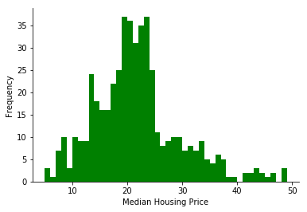

```python
# prepare your jupyter notebook to work with matplotlib and import the library to something convenient
%matplotlib inline
import matplotlib.pyplot as plt

# edit the code below to make the graph look good
ax = plt.subplot(111)
plt.hist(bdata.target, color="green", bins=np.arange(min(bdata.target), max(bdata.target), 1)) #1 = $1000 in this dataset
plt.xlabel('Median Housing Price')
plt.ylabel('Frequency')
ax.spines['right'].set_visible(False)
ax.spines['top'].set_visible(False)
```

### 1.2: Scatter plot of housing prices and crime

Use matplotlib to create a scatter plot that shows the relationship between the median value of the home (y-axis) and the per-capita crime rate (x-axis). Properly label your axes, and make sure that your graphic looks polished and professional.

[figure not shown]

```python
ax = plt.subplot(111)
plt.scatter(bdata.data[:,1], bdata.target)
plt.ylabel('Median Housing Price')
plt.xlabel('Per-capita Crime Rate')
plt.title('Crime and home prices')
ax.spines['right'].set_visible(False)
ax.spines['top'].set_visible(False)
```

### 1.3 Create your own (creative and effective) visualization

Use another type of graph or chart to illustrate an interesting pattern in the data. Be creative in your visualization, and make sure to produce a "publication-quality" graph. Points will be given for useful and creative graphs; points will be deducted for confusing issues like unlabeled axes. If you're new to data visualization, [this guide](http://pubs.aeaweb.org/doi/pdfplus/10.1257/jep.28.1.209) is a good place to start.

First we're going to explore all the of the variables with a scatterplot matrix so we can immediately recognize strong relationships. While not publication quality, it is useful.

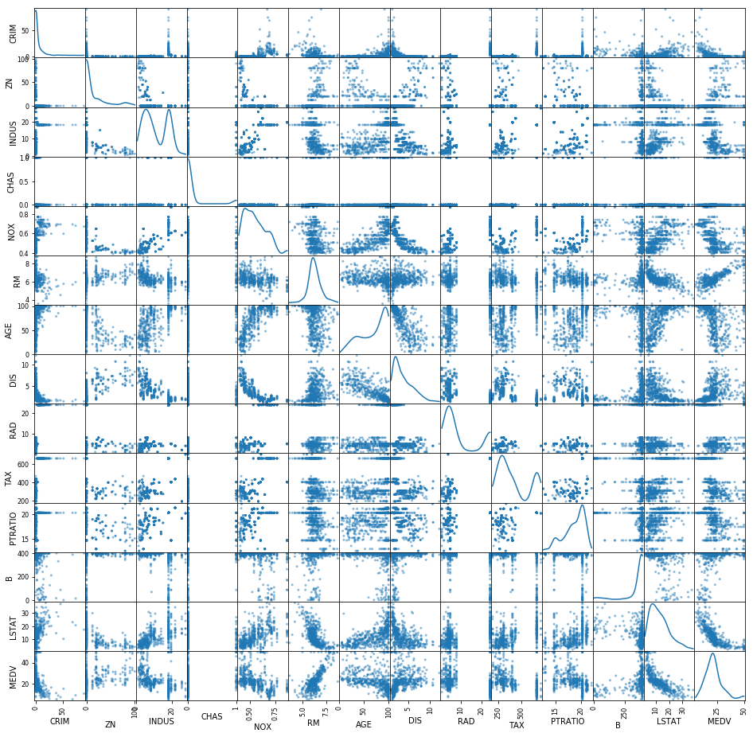

```python
from pandas.plotting import scatter_matrix

# create a dataframe so we can use pandas functions
bdat = pd.DataFrame(data=bdata.data, columns=bdata.feature_names)
bdat['MEDV'] = bdata.target

# explore the variables with a scatterplot matrix
axs=scatter_matrix(bdat, figsize=(16, 16), diagonal='kde')
axs[0,0].get_figure().show()
```

From this plot, we see that MEDV is strongly correlated with LSTAT and RM. To visualize this multidimensional relationship, we can use multiple plotting elements -- in this case, size.

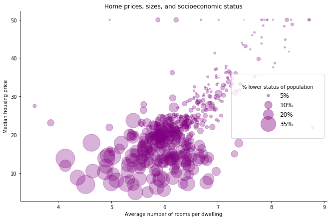

```python
plt.figure(figsize=(11,7))
ax = plt.subplot(111)
sizes = (bdat['LSTAT'])**2
plt.scatter(bdat['RM'], bdat['MEDV'], s=sizes, alpha=0.3, color="purple")
plt.ylabel('Median housing price')
plt.xlabel('Average number of rooms per dwelling')
plt.title('Home prices, sizes, and socioeconomic status')
ax.spines['right'].set_visible(False)
ax.spines['top'].set_visible(False)
ax.legend()

msizes = np.array([5, 15, 20, 30]) # set size of marker for legend

l1, = plt.plot([],[], 'or', markersize=msizes[0], color="purple", alpha=0.4) #legend items
l2, = plt.plot([],[], 'or', markersize=msizes[1], color="purple", alpha=0.4)
l3, = plt.plot([],[], 'or', markersize=msizes[2], color="purple", alpha=0.4)
l4, = plt.plot([],[], 'or', markersize=msizes[3], color="purple", alpha=0.4)

labels = ['5%', '10%', '20%', '35%'] # legend labels

leg = plt.legend([l1, l2, l3, l4], labels, ncol=1, frameon=True, fontsize=12, # create legend
handlelength=2, loc = 5, borderpad = 1.8,
handletextpad=1, title='% lower status of population', scatterpoints = 1)
```

## Part 2: Experimental Setup

The goal of the next few sections is to design an experiment to predict the median home value for an instance in the data.

### 2.1 Begin by writing a function to compute the Root Mean Squared Error for a list of numbers

You can find the sqrt function in the Numpy package. Furthermore the details of RMSE can be found on [Wikipedia](http://en.wikipedia.org/wiki/Root-mean-square_deviation)

```python
"""
Function
--------
compute_rmse

Given two arrays, one of actual values and one of predicted values,
compute the Roote Mean Squared Error

Parameters
----------
predictions : array
    Array of numerical values corresponding to predictions for each of the N observations

yvalues : array
    Array of numerical values corresponding to the actual values for each of the N observations

Returns
-------
rmse : int
    Root Mean Squared Error of the prediction

Example
-------
>>> print compute_rmse((2,2,3),(0,2,6)
2.16
"""
def compute_rmse(predictions, yvalues):
    rmse = math.sqrt((sum((predictions - yvalues)**2))/len(yvalues))
    return rmse

y_hat = np.array([2,2,3])
y = np.array([0,2,6])
compute_rmse(y_hat,y)
```

```
2.0816659994661326
```

### 2.2 Divide your data into training and testing datasets

Randomly select 66% of the data and put this in a training dataset (call this "bdata_train"), and place the remaining 34% in a testing dataset (call this "bdata_test")

```python
# leave the following line untouched, it will help ensure that your "random" split is the same "random" split used by the rest of the class
np.random.seed(seed=13579)

bdat_train, bdat_test = train_test_split(bdat, test_size = 0.34) # split data into 66% train, 34% test
```

### 2.3 Use a very bad baseline for prediction, and compute RMSE

Create a model that predicts, for every observation $x_i$, that the median home value is the average (mean) of the median values for all instances in the training set. Compute the RMSE on the training set. Now compute the RMSE on the test data set (but use the model you trained on the training set!). How does RMSE compare for training vs. testing datasets? Is this what you expected, and why?

```python
# first create our bad model
def bad_model(target):
    y_hat = np.ones(len(target)) * np.mean(target)
    return y_hat

y_hat = bad_model(bdat_train.MEDV)
y = bdat_train.MEDV
compute_rmse(y_hat, y)
```

```
9.430689678794845
```

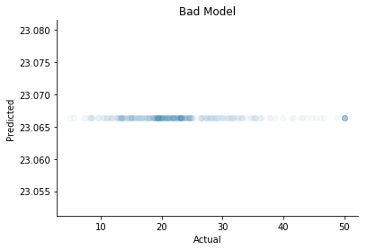

```python
# What does it look like when we plot it?

ax = plt.subplot(111)
plt.scatter(y, y_hat, alpha=0.03)
plt.ylabel('Predicted')
plt.xlabel('Actual')
plt.title('Bad Model')
ax.spines['right'].set_visible(False)
ax.spines['top'].set_visible(False)
```

**Observations**

## Part 3: Nearest Neighbors

### 3.1 Nearest Neighbors: Distance function

Let's try and build a machine learning algorithm to beat the "Average Value" baseline that you computed above. Soon you will implement the Nearest Neighbor algorithm, but first you need to create a distance metric to measure the distance (and similarity) between two instances. Write a generic function to compute the L-Norm distance (called the *p*-norm distance on Wikipedia). Verify that your function works by computing the Euclidean distance between the points (3,4) and (6,8).

```python
"""
Function
--------
distance

Given two instances and a value for L, return the L-Norm distance between them

Parameters
----------
x1, x2 : array
    Array of numerical values corresponding to predictions for each of the N observations

L: int
    Value of L to use in computing distances

Returns
-------
dist : int
    The L-norm distance between instances

Example
-------
>>> print distance((3,4),(6,8),2)
7

"""
# distance function for arrays
def distance(x1, x2, L): # where x1 is array of instances (any size) and x2 is query data
    dist = (np.sum(abs(x1-x2)**L, axis=1))**(1/L)
    return dist

print(distance(np.array([[3,4]]),np.array([[6,8]]), 2))
```

```
[5.]
```

### 3.2 Basic Nearest Neighbor algorithm

Now things get fun. Your task is to implement a basic nearest neighbor algorithm from scratch. Your simple model will use two input features (CRIM and RM) and a single output (MEDV). In other words, you are modelling the relationship between median home value and crime rates and house size.

Use your training data (bdata_train) to "fit" your model, although as you know, with Nearest Neighbors there is no real training, you just need to keep your training data in memory. Write a function that predicts, for each instance in the testing data (bdata_test), the median home value using the nearest neighbor algorithm we discussed in class. Since this is a small dataset, you can simply compare your test instance to every instance in the training set, and return the MEDV value of the closest training instance. Have your function take L as an input, where L is passed to the distance function.

Compute the RMSE for the Nearest Neighbor predictions on the test set, using the Euclidean distance. Report an estimate of the total time taken by your code to predict the nearest neighbors for all the values in the test data set.

```python
"""
Function
--------
nneighbor

Given an instance, finds target value of nearest neighbor in the training feature space.

Parameters
---------
train : array
    Selected features in training data with target feature as the last column

test : array
    Selected features in test data with target feature as the last column

L : int
    Value of L to use in computing distances

Returns
-------
rmse : int
    Root Mean Squared Error of the prediction

Example
-------
>>> nneighbor(np.array([[1,4,5],[9,8,5]]), np.array([[8,4,3],[1,7,8]]), 2)
array([5., 5.])
"""
from operator import itemgetter
import time

def nneighbor(train, test, L):
    start_time = time.time()
    yhat = np.zeros(len(test)) # empty array to hold predicted values for test instances
    for j in range(0,len(test)):
        distances = np.zeros((len(train), 2)) # empty array to hold distances
        dist = distance(train[:,0:len(train[1])-1], test[j,0:len(test[1])-1], L) # find distances between test point j and all training points
        distances[:,0], distances[:,1] = dist, train[:,-1] # add distances and target value to array
        distances = distances[distances[:,0].argsort()] # sort by shortest distance
        yhat[j] = distances[0,1] # add target value of nearest neighbor to yhat
    print("Time taken: " + str(round(time.time() - start_time,2)) + " seconds")
    return yhat # return predicted target values

# get two columns of interest into array where each row is an instance
x1 = np.array([bdat_train['CRIM'], bdat_train['RM'], bdat_train['MEDV']]).T # training data
x2 = np.array([bdat_test['CRIM'], bdat_test['RM'], bdat_test['MEDV']]).T # test data

# run it!
preds1 = nneighbor(x1,x2,2) # why are there so many columns???

# compute RMSE
compute_rmse(preds1, x2[:,len(x2[1])-1])
```

```
Time taken: 0.01 seconds
```

```
6.681010099809551
```

This might be good or bad, I'm not too familiar with what constitutes a "bad" RMSE. So let's plot the actual vs. predicted values to see how closely they align to a perfect $y = \hat{y}$

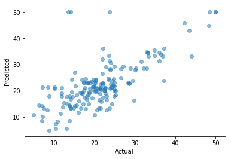

```python
# let's plot actual vs. predicted MEDV values to see how well we did
ax = plt.subplot(111)
plt.scatter(x2[:,len(x2[1])-1], preds1, alpha=0.5)
plt.ylabel('Predicted')
plt.xlabel('Actual')
ax.spines['right'].set_visible(False)
ax.spines['top'].set_visible(False)
```

### 3.3 Results and Normalization

If you were being astute, you would have noticed that we never normalized our features -- a big no-no with Nearest Neighbor algorithms. Write a generic normalization function that takes as input an array of values for a given feature, and returns the normalized array (subtract the mean and divide by the standard deviation).

Re-run the Nearest Neighbor algorithm on the normalized dataset (still just using CRIM and RM as input), and compare the RMSE from this method with your previous RMSE evaluations.

*NOTE*: To normalize properly, best practice is to compute the mean and standard deviation on the training set, and use these values to normalize the testing dataset. However, for this problem set, it is okay if you separately normalize each dataset using the respective mean and standard deviation.

```python
"""
Function
--------
normalize

Normalizes each feature of a dataset by subtracting mean of feature and dividing by standard deviation of feature

Parameters
---------
raw_data : DataFrame
    Selected features with target feature as the last column

Returns
-------
normalized_data : DataFrame
    Normalized data

Example
-------
>>> p=pd.DataFrame({'one' : [1., 2., 3., 4.],
                'two' : [4., 3., 2., 1.]})
>>> normalize(p)
"""
def normalize(raw_data):
    feats = len(raw_data.columns)-1 # last column of raw_data is target feature
    normalized_data = raw_data.copy() # set normalized data equal to raw input data
    colmeans = raw_data.iloc[:,0:feats].mean(axis=0) # get means of each feature except target
    colsds = raw_data.iloc[:,0:feats].std(axis=0) # get SD of each feature except target
    normalized_data.iloc[:,0:feats] = (raw_data.iloc[:,0:feats] - colmeans) / colsds # normalize features except target
    return normalized_data

bdat_train_norm = normalize(bdat_train) # normalize training data separately
bdat_test_norm = normalize(bdat_test) # normalize testing data separately

x1_norm = np.array([bdat_train_norm['CRIM'], bdat_train_norm['RM'], bdat_train_norm['MEDV']]).T # create array of selected training features
x2_norm = np.array([bdat_test_norm['CRIM'], bdat_test_norm['RM'], bdat_test_norm['MEDV']]).T # create array of selected testing features

preds2 = nneighbor(x1_norm, x2_norm, 2) # run nneighbors with normalized data

compute_rmse(preds2, x2_norm[:,len(x2[1])-1]) # compute RMSE
```

```
Time taken: 0.02 seconds
```

```
6.802400970211737
```

### 3.4 Optimization

A lot of the decisions we've made so far have been arbitrary. Try to increase the performance of your nearest neighbor algorithm by adding features that you think might be relevant, and by using different values of L in the distance function. Try a model that uses a different set of 2 features, then try at least one model that uses more than 4 features, then try using a different value of L. If you're having fun, try a few different combinations of features and L!

What combination of features and distance function provide the lowest RMSE? Do your decisions affect the running time of the algorithm?

```python
bdat.corr() # check correlation between variables
```

|  | CRIM | ZN | INDUS | CHAS | NOX | RM | AGE | DIS | RAD | TAX | PTRATIO | B | LSTAT | MEDV |
| --- | --- | --- | --- | --- | --- | --- | --- | --- | --- | --- | --- | --- | --- | --- |
| CRIM | 1.000000 | -0.199458 | 0.404471 | -0.055295 | 0.417521 | -0.219940 | 0.350784 | -0.377904 | 0.622029 | 0.579564 | 0.288250 | -0.377365 | 0.452220 | -0.385832 |
| ZN | -0.199458 | 1.000000 | -0.533828 | -0.042697 | -0.516604 | 0.311991 | -0.569537 | 0.664408 | -0.311948 | -0.314563 | -0.391679 | 0.175520 | -0.412995 | 0.360445 |
| INDUS | 0.404471 | -0.533828 | 1.000000 | 0.062938 | 0.763651 | -0.391676 | 0.644779 | -0.708027 | 0.595129 | 0.720760 | 0.383248 | -0.356977 | 0.603800 | -0.483725 |
| CHAS | -0.055295 | -0.042697 | 0.062938 | 1.000000 | 0.091203 | 0.091251 | 0.086518 | -0.099176 | -0.007368 | -0.035587 | -0.121515 | 0.048788 | -0.053929 | 0.175260 |
| NOX | 0.417521 | -0.516604 | 0.763651 | 0.091203 | 1.000000 | -0.302188 | 0.731470 | -0.769230 | 0.611441 | 0.668023 | 0.188933 | -0.380051 | 0.590879 | -0.427321 |
| RM | -0.219940 | 0.311991 | -0.391676 | 0.091251 | -0.302188 | 1.000000 | -0.240265 | 0.205246 | -0.209847 | -0.292048 | -0.355501 | 0.128069 | -0.613808 | 0.695360 |
| AGE | 0.350784 | -0.569537 | 0.644779 | 0.086518 | 0.731470 | -0.240265 | 1.000000 | -0.747881 | 0.456022 | 0.506456 | 0.261515 | -0.273534 | 0.602339 | -0.376955 |
| DIS | -0.377904 | 0.664408 | -0.708027 | -0.099176 | -0.769230 | 0.205246 | -0.747881 | 1.000000 | -0.494588 | -0.534432 | -0.232471 | 0.291512 | -0.496996 | 0.249929 |
| RAD | 0.622029 | -0.311948 | 0.595129 | -0.007368 | 0.611441 | -0.209847 | 0.456022 | -0.494588 | 1.000000 | 0.910228 | 0.464741 | -0.444413 | 0.488676 | -0.381626 |
| TAX | 0.579564 | -0.314563 | 0.720760 | -0.035587 | 0.668023 | -0.292048 | 0.506456 | -0.534432 | 0.910228 | 1.000000 | 0.460853 | -0.441808 | 0.543993 | -0.468536 |
| PTRATIO | 0.288250 | -0.391679 | 0.383248 | -0.121515 | 0.188933 | -0.355501 | 0.261515 | -0.232471 | 0.464741 | 0.460853 | 1.000000 | -0.177383 | 0.374044 | -0.507787 |
| B | -0.377365 | 0.175520 | -0.356977 | 0.048788 | -0.380051 | 0.128069 | -0.273534 | 0.291512 | -0.444413 | -0.441808 | -0.177383 | 1.000000 | -0.366087 | 0.333461 |
| LSTAT | 0.452220 | -0.412995 | 0.603800 | -0.053929 | 0.590879 | -0.613808 | 0.602339 | -0.496996 | 0.488676 | 0.543993 | 0.374044 | -0.366087 | 1.000000 | -0.737663 |
| MEDV | -0.385832 | 0.360445 | -0.483725 | 0.175260 | -0.427321 | 0.695360 | -0.376955 | 0.249929 | -0.381626 | -0.468536 | -0.507787 | 0.333461 | -0.737663 | 1.000000 |

Looks like LSTAT, PTRATIO, and INDUS are the highest variables (pos or neg), ignoring RM

```
Time taken: 0.01 seconds
5.606684697287487
Time taken: 0.01 seconds
4.536174446900907
Time taken: 0.04 seconds
4.405638793545237
Time taken: 0.04 seconds
4.376659057851149
```

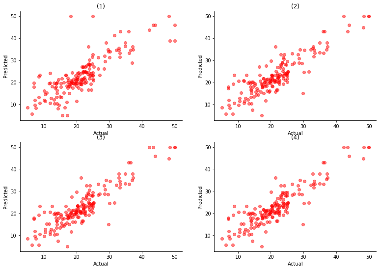

```python
#=========== nneighbor with PTRATIO and LSTAT
x1 = np.array([bdat_train_norm['LSTAT'], bdat_train_norm['RM'], bdat_train_norm['MEDV']]).T # training data
x2 = np.array([bdat_test_norm['LSTAT'], bdat_test_norm['RM'], bdat_test_norm['MEDV']]).T # test data
preds3 = nneighbor(x1,x2,2)
print(compute_rmse(preds3, x2[:,len(x2[1])-1]))

plt.figure(figsize=(13,9))
ax = plt.subplot(221)
plt.scatter(x2[:,len(x2[1])-1], preds3, alpha=0.5, color="red")
plt.ylabel('Predicted')
plt.xlabel('Actual')
plt.title('(1)')
ax.spines['right'].set_visible(False)
ax.spines['top'].set_visible(False)

#=========== nneighbor with LSTAT, INDUS, RM, and PTRATIO
x1 = np.array([bdat_train_norm['LSTAT'], bdat_train_norm['RM'],
               bdat_train_norm['PTRATIO'], bdat_train_norm['INDUS'], bdat_train_norm['MEDV']]).T # training data
x2 = np.array([bdat_test_norm['LSTAT'], bdat_test_norm['RM'],
               bdat_test_norm['PTRATIO'], bdat_test_norm['INDUS'], bdat_test_norm['MEDV']]).T # test data
preds4 = nneighbor(x1,x2,2)
print(compute_rmse(preds4, x2[:,len(x2[1])-1]))

ax = plt.subplot(222)
plt.scatter(x2[:,len(x2[1])-1], preds4, alpha=0.5, color="red")
plt.ylabel('Predicted')
plt.xlabel('Actual')
plt.title('(2)')
ax.spines['right'].set_visible(False)
ax.spines['top'].set_visible(False)

#=========== nneighbor with LSTAT, INDUS, RM, and PTRATIO and L = 3
x1 = np.array([bdat_train_norm['LSTAT'], bdat_train_norm['RM'],
               bdat_train_norm['PTRATIO'], bdat_train_norm['INDUS'], bdat_train_norm['MEDV']]).T # training data
x2 = np.array([bdat_test_norm['LSTAT'], bdat_test_norm['RM'],
               bdat_test_norm['PTRATIO'], bdat_test_norm['INDUS'], bdat_test_norm['MEDV']]).T # test data
preds5 = nneighbor(x1,x2,3)
print(compute_rmse(preds5, x2[:,len(x2[1])-1]))

ax = plt.subplot(223)
plt.scatter(x2[:,len(x2[1])-1], preds5, alpha=0.5, color="red")
plt.ylabel('Predicted')
plt.xlabel('Actual')
plt.title('(3)')
ax.spines['right'].set_visible(False)
ax.spines['top'].set_visible(False)

#=========== nneighbor with LSTAT, INDUS, RM, and PTRATIO and L = 5
x1 = np.array([bdat_train_norm['LSTAT'], bdat_train_norm['RM'],
               bdat_train_norm['PTRATIO'], bdat_train_norm['INDUS'], bdat_train_norm['MEDV']]).T # training data
x2 = np.array([bdat_test_norm['LSTAT'], bdat_test_norm['RM'],
               bdat_test_norm['PTRATIO'], bdat_test_norm['INDUS'], bdat_test_norm['MEDV']]).T # test data
preds6 = nneighbor(x1,x2,5)
print(compute_rmse(preds6, x2[:,len(x2[1])-1]))

ax = plt.subplot(224)
plt.scatter(x2[:,len(x2[1])-1], preds6, alpha=0.5, color="red")
plt.ylabel('Predicted')
plt.xlabel('Actual')
plt.title('(4)')
ax.spines['right'].set_visible(False)
ax.spines['top'].set_visible(False)
```

With each model (displayed above) the model gets better and better at fitting to the data. Adding more correlated variables and increasing L reduced the RMSE, though with diminishing returns.

### 3.5 Cross-Validation

The more you tinkered with your features and distance function, the higher the risk that you overfit your training data. To prevent this sort of overfitting, you need to use cross-validation (see K-fold cross-validation). Here you must implement a simple k-fold cross-validation algorithm yourself. The function you write here will be used several more times in this problem set, so do your best to write efficient code! (Note that the sklearn package has a built-in [K-fold](http://scikit-learn.org/stable/modules/cross_validation.html#cross-validation) iterator -- you should *not* be invoking that or any related algorithms in this section of the problem set.)

Use 10-fold cross-validation and report the average RMSE for Nearest Neighbors using Euclidean distance with CRIM and RM input features, as well as the total running time for the full run of 10 folds. In other words, randomly divide your dataset into 10 equally-sized samples, and for each of 10 iterations (the "folds"), use 9 samples as "training data" (even though there is no training in k-NN!), and the remaining 1 sample for testing. Compute the RMSE of that particular test set, then move on to the next iteration. Report the average RMSE across the 10 iterations.

```python
"""
Function
--------
kfold_crossval

Given a dataset and number of folds, k, returns indices in dataset corresponding to test and training instances for k number of iterations

Parameters
----------
data : array
    Array of data

k : integer
    Number of folds in cross validation

Returns
-------
kfolds : list
    List of k-lists with indices of the dataset rows contained in each fold.
    Can index the dataset to return train/test split for every fold.
"""
import random
from random import randrange

def kfold_crossval(data, k):
    fold_size = int(len(data)/k) # find how big folds must be for k-number of folds
    rows = list(range(len(data))) # a list of indices for each row in the dataset from which we will randomly pick folds
    data_split = [] # holds indices of folds ("test" data)
    for i in range(k):
        fold = [] # holds four fold indices
        while len(fold) < fold_size:
            ind = randrange(len(rows)) # randomly pulls one row
            fold.append(rows.pop(ind)) # appends the row and also removes it from the list of rows so it can't be pulled again
        data_split.append(fold) # adds the list of four fold indices to list of lists
    return data_split

#================ Get k-folds
x1 = np.array([bdat_train_norm['CRIM'], bdat_train_norm['RM'], bdat_train_norm['MEDV']]).T # create array of training data
kfolds = kfold_crossval(x1, 10) # run it! get folds

#================ Use k-folds to iterate through nearest neighbors model
rmse = [] # list for RMSEs
rows = list(range(len(x1))) # list of dataset indices
for i in range(len(kfolds)):
    train = x1[[x for x in rows if x not in kfolds[i]], :2] # train data = slice of dataset corresponding to NOT k-folds
    test = x1[kfolds[i], :2] # test data = slice of dataset corresponding to k-folds
    preds = nneighbor(train, test, 2) # run nearest neighbors
    rmse.append(compute_rmse(preds, test[:,len(test[1])-1])) # get RMSE

sum(rmse)/len(rmse) # mean of RMSEs
```

```
Time taken: 0.0 seconds
Time taken: 0.0 seconds
Time taken: 0.0 seconds
Time taken: 0.0 seconds
Time taken: 0.0 seconds
Time taken: 0.0 seconds
Time taken: 0.0 seconds
Time taken: 0.0 seconds
Time taken: 0.0 seconds
Time taken: 0.0 seconds
```

```
1.3039444323530334
```

### 3.6 K-Nearest Neighbors Algorithm

Implement the K-Nearest Neighbors algorithm. Using 10-fold cross validation, report the RMSE for K=3 and the running time of the algorithm.

```python
"""
Function
--------
knn

Given a dataset and number of folds, k, returns indices in dataset corresponding to test and training instances for k number of iterations

Parameters
----------
train : array
    Array of data

k : integer
    Number of folds in cross validation

Returns
-------
yhat : array
    Predicted target values of test data
"""
def knn(train, test, L, K):
    start_time = time.time()
    yhat = np.zeros(len(test)) # empty array to hold predicted values for test instances
    for j in range(0,len(test)):
        distances = np.zeros((len(train), 2)) # empty array to hold distances
        dist = distance(train[:,0:len(train[1])-1], test[j,0:len(test[1])-1], L) # find distances between test point j and all training points
        distances[:,0], distances[:,1] = dist, train[:,-1] # add distances and target value to array
        distances = distances[distances[:,0].argsort()] # sort by shortest distance
        yhat[j] = np.mean(distances[K-1,1]) # add mean target value of k-nearest neighbors to yhat
    print("Time taken: " + str(round(time.time() - start_time, 2)) + " seconds")
    return yhat # return predicted target values

x1 = np.array([bdat_train_norm['CRIM'], bdat_train_norm['RM'], bdat_train_norm['MEDV']]).T # training data
x2 = np.array([bdat_test_norm['CRIM'], bdat_test_norm['RM'], bdat_test_norm['MEDV']]).T # test data

preds = knn(x1, x2, 2, 3) # get target value predictions for K=3
compute_rmse(preds, x2[:,len(x2[1])-1]) # compute RMSE
```

```
Time taken: 0.02 seconds
```

```
8.268426610469295
```

### 3.7 Using cross validation to find K

What is the best choice of K? Compute the RMSE for values of K between 1 and 25 using 10-fold cross-validation. Use the following features in your model, and don't forget to normalize: CRIM, ZN, RM, AGE, DIS, TAX. Create a graph that shows how RMSE changes as K increases from 1 to 25. Label your axes, and summarize what you see. What do you think is a reasonable choice of K for this model?

```python
#================== Select features
x1 = np.array([bdat_train_norm['CRIM'], bdat_train_norm['ZN'], bdat_train_norm['RM'], # train data
               bdat_train_norm['AGE'], bdat_train_norm['DIS'], bdat_train_norm['TAX'],
               bdat_train_norm['MEDV']]).T
x2 = np.array([bdat_test_norm['CRIM'], bdat_test_norm['ZN'], bdat_test_norm['RM'], # test data
               bdat_test_norm['AGE'], bdat_test_norm['DIS'], bdat_test_norm['TAX'],
               bdat_test_norm['MEDV']]).T

#================== Cross-validation to find K
myK = list(range(25)) # K values to try
rmse = [] # holds RMSE values and K values from cross-validation tuning of K
rmse_K = [] # list for one cross-validated RMSE per K

for K in myK:
    kfolds = kfold_crossval(x1, 10) # run it! get folds
    rows = list(range(len(x1))) # list of dataset indices
    for i in range(len(kfolds)):
        rmse_cv = [] # list for one RMSE per fold
        train = x1[[x for x in rows if x not in kfolds[i]], :2] # train data
        test = x1[kfolds[i], :2] # test data (i.e. the fold)
        preds = knn(train, test, 2, K) # get predicted values from KNN
        rmse_cv.append(compute_rmse(preds, test[:,len(test[1])-1])) # get RMSE of KNN run
    rmse_K.append(sum(rmse_cv)/len(rmse_cv)) # append mean of RMSEs for K

rmse = [[myK], [rmse_K]]
```

[output not shown]

[output cut: 195 more lines]

```
Time taken: 0.0 seconds
Time taken: 0.0 seconds
Time taken: 0.0 seconds
Time taken: 0.0 seconds
Time taken: 0.0 seconds
Time taken: 0.0 seconds
Time taken: 0.0 seconds
Time taken: 0.0 seconds
Time taken: 0.0 seconds
Time taken: 0.0 seconds
Time taken: 0.0 seconds
Time taken: 0.0 seconds
Time taken: 0.0 seconds
Time taken: 0.0 seconds
Time taken: 0.0 seconds
```

[figure not shown]

```python
plt.figure(figsize=(9,6))
ax = plt.subplot(111)
plt.plot(rmse[0][0],rmse[1][0], color="red")
plt.ylabel('K Values')
plt.xlabel('RMSE')
plt.title('Cross-validation to find K')
ax.spines['right'].set_visible(False)
ax.spines['top'].set_visible(False)
```

Based on this model, 10 seems to be the best value for K because it yields the lowest RMSE. (However, re-running it again gives me different answers. I suspect the best practices way to do this may be to stratify the data and make sure the summary stats of each fold are relatively similar).